# Fall 2019 PSY 737 Final

# State.x77

matrix with 50 rows and 8 columns giving the following statistics in the respective columns.

| Variable | Variable Description |
| --- | --- |
| Population | Population estimate as of July 1, 1975 |
| Income | Per capita income (1974) |
| Illiteracy | Illiteracy (1970, percent of population) |
| Life Exp | Life expectancy in years (1969–71) |
| Murder | murder and non-negligent manslaughter rate per 100,000 population (1976) |
| HS Grad | Percent high-school graduates (1970) |
| Frost | mean number of days with minimum temperature below freezing (1931–1960) in capital or large city |
| Area | Land area in square miles |

## Source

U.S. Department of Commerce, Bureau of the Census (1977) Statistical Abstract of the United States.

U.S. Department of Commerce, Bureau of the Census (1977) County and City Data Book.

### References

Becker, R. A., Chambers, J. M. and Wilks, A. R. (1988) The New S Language. Wadsworth & Brooks/Cole.

```r
attach(data)
summary(data)
```

```
##    Population        Income       Illiteracy       Life.Exp
##  Min.   :  365   Min.   :3098   Min.   :0.500   Min.   :67.96
##  1st Qu.: 1080   1st Qu.:3993   1st Qu.:0.625   1st Qu.:70.12
##  Median : 2838   Median :4519   Median :0.950   Median :70.67
##  Mean   : 4246   Mean   :4436   Mean   :1.170   Mean   :70.88
##  3rd Qu.: 4968   3rd Qu.:4814   3rd Qu.:1.575   3rd Qu.:71.89
##  Max.   :21198   Max.   :6315   Max.   :2.800   Max.   :73.60
##      Murder          HS.Grad          Frost             Area
##  Min.   : 1.400   Min.   :37.80   Min.   :  0.00   Min.   :  1049
##  1st Qu.: 4.350   1st Qu.:48.05   1st Qu.: 66.25   1st Qu.: 36985
##  Median : 6.850   Median :53.25   Median :114.50   Median : 54277
##  Mean   : 7.378   Mean   :53.11   Mean   :104.46   Mean   : 70736
##  3rd Qu.:10.675   3rd Qu.:59.15   3rd Qu.:139.75   3rd Qu.: 81162
##  Max.   :15.100   Max.   :67.30   Max.   :188.00   Max.   :566432
```

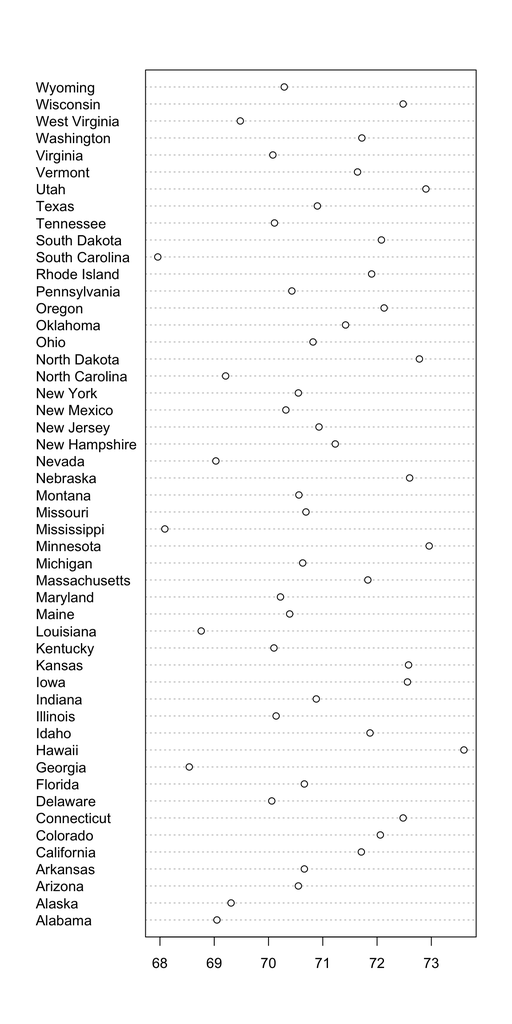

```r
dotchart(Life.Exp, row.names(data))
```

1. The state that had the highest life expectancy was Hawaii.
2. The state that had the lowest life exectancy was South Carolina.

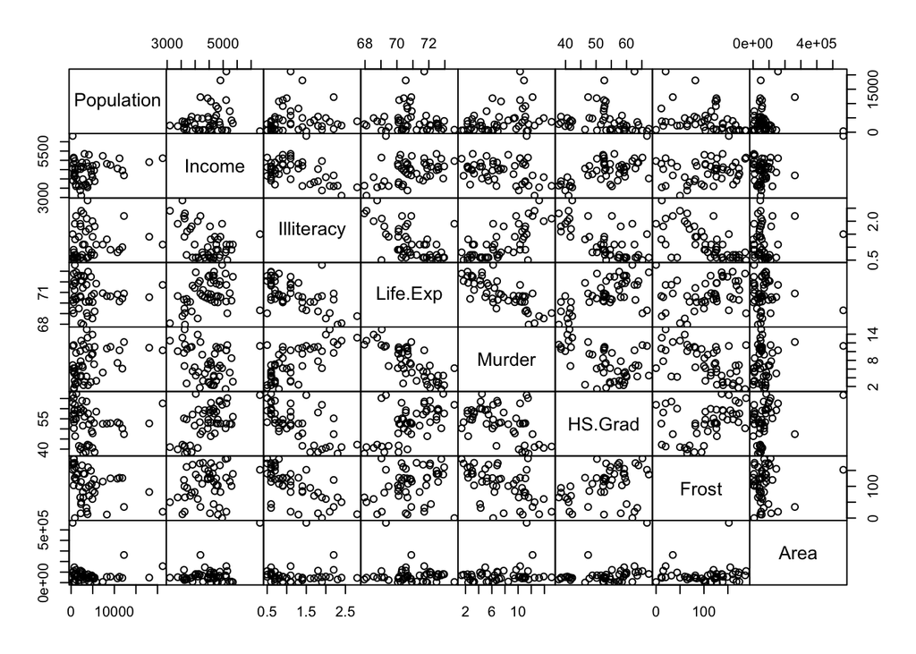

```r
 pairs(data, gap=0)
```

1. Pairs that appear to have a linear relationship with Like Exp. is Illiteracy, Murder, Income, and HS Grad.
2. Pairs that do not have a linear relationship with Life Exp. are Population, Frost, and Area.

```r
cor(data)
```

```
##             Population     Income  Illiteracy    Life.Exp     Murder
## Population  1.00000000  0.2082276  0.10762237 -0.06805195  0.3436428
## Income      0.20822756  1.0000000 -0.43707519  0.34025534 -0.2300776
## Illiteracy  0.10762237 -0.4370752  1.00000000 -0.58847793  0.7029752
## Life.Exp   -0.06805195  0.3402553 -0.58847793  1.00000000 -0.7808458
## Murder      0.34364275 -0.2300776  0.70297520 -0.78084575  1.0000000
## HS.Grad    -0.09848975  0.6199323 -0.65718861  0.58221620 -0.4879710
## Frost      -0.33215245  0.2262822 -0.67194697  0.26206801 -0.5388834
## Area        0.02254384  0.3633154  0.07726113 -0.10733194  0.2283902
##                HS.Grad      Frost        Area
## Population -0.09848975 -0.3321525  0.02254384
## Income      0.61993232  0.2262822  0.36331544
## Illiteracy -0.65718861 -0.6719470  0.07726113
## Life.Exp    0.58221620  0.2620680 -0.10733194
## Murder     -0.48797102 -0.5388834  0.22839021
## HS.Grad     1.00000000  0.3667797  0.33354187
## Frost       0.36677970  1.0000000  0.05922910
## Area        0.33354187  0.0592291  1.00000000
```

1. Variables that correlate most strongly with Life Expectancy are Murder, HS. Grad, Illiteracy, and Income (weakest, but still noteable).
2. The ones that correlate least strongly are Area, Population, and Frost (Income could be considered weak if .3-.49 is the cut off for weak).

```r
cor.test(Life.Exp, Frost)
```

```
##
##  Pearson's product-moment correlation
##
## data:  Life.Exp and Frost
## t = 1.8814, df = 48, p-value = 0.06599
## alternative hypothesis: true correlation is not equal to 0
## 95 percent confidence interval:
##  -0.01756069  0.50367466
## sample estimates:
##      cor
## 0.262068
```

Using p<.05 as my standard to reject the null hypotheisis, I would say there is a nonsignificant relationship between Life.Exp and Frost. Not only is the p>. 05, but the confidence interval also crosses zero. The result t(48)=1.881 is nonsignificant.

```r
lm(Life.Exp ~ Murder + HS.Grad + Frost)
```

```
##
## Call:
## lm(formula = Life.Exp ~ Murder + HS.Grad + Frost)
##
## Coefficients:
## (Intercept)       Murder      HS.Grad        Frost
##   71.036379    -0.283065     0.049949    -0.006912
```

```r
Frog<- lm(Life.Exp ~ Murder + HS.Grad + Frost)
summary(Frog)
```

```
##
## Call:
## lm(formula = Life.Exp ~ Murder + HS.Grad + Frost)
##
## Residuals:
##     Min      1Q  Median      3Q     Max
## -1.5015 -0.5391  0.1014  0.5921  1.2268
##
## Coefficients:
##              Estimate Std. Error t value Pr(>|t|)
## (Intercept) 71.036379   0.983262  72.246  < 2e-16 ***
## Murder      -0.283065   0.036731  -7.706 8.04e-10 ***
## HS.Grad      0.049949   0.015201   3.286  0.00195 **
## Frost       -0.006912   0.002447  -2.824  0.00699 **
## ---
## Signif. codes:  0 '***' 0.001 '**' 0.01 '*' 0.05 '.' 0.1 ' ' 1
##
## Residual standard error: 0.7427 on 46 degrees of freedom
## Multiple R-squared:  0.7127, Adjusted R-squared:  0.6939
## F-statistic: 38.03 on 3 and 46 DF,  p-value: 1.634e-12
```

```r
anova(Frog)
```

```
## Analysis of Variance Table
##
## Response: Life.Exp
##           Df Sum Sq Mean Sq F value    Pr(>F)
## Murder     1 53.838  53.838 97.6103 5.971e-13 ***
## HS.Grad    1  4.691   4.691  8.5050  0.005459 **
## Frost      1  4.399   4.399  7.9751  0.006988 **
## Residuals 46 25.372   0.552
## ---
## Signif. codes:  0 '***' 0.001 '**' 0.01 '*' 0.05 '.' 0.1 ' ' 1
```

1. The multipe R-Squared for the regression model is 0.7127
2. All three contribute to the prediction of Lfe. Exp. at a significant level.

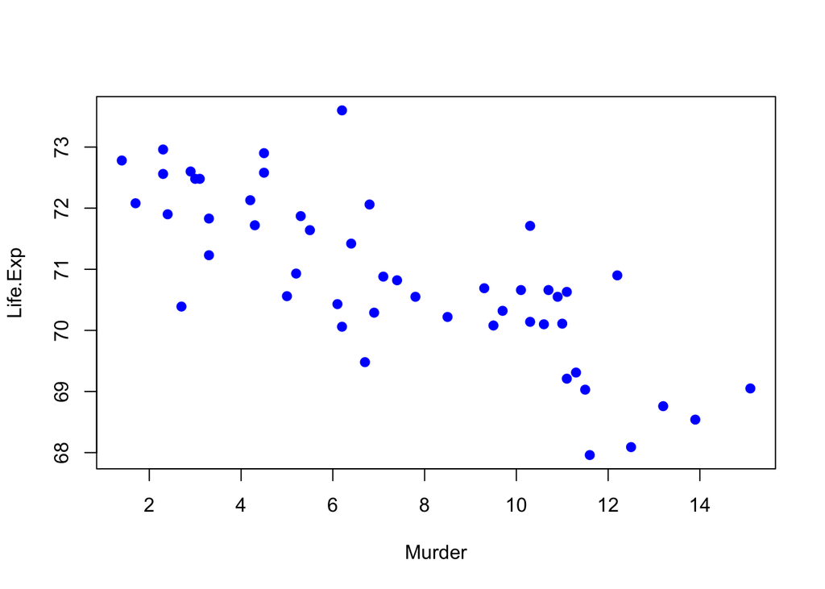

[output not shown]

```r
plot( Murder, Life.Exp, pch=19, col="blue")
```

```r
subset(data, rownames(data)== "Georgia")
```

```
##         Population Income Illiteracy Life.Exp Murder HS.Grad Frost  Area
## Georgia       4931   4091          2    68.54   13.9    40.6    60 58073
```

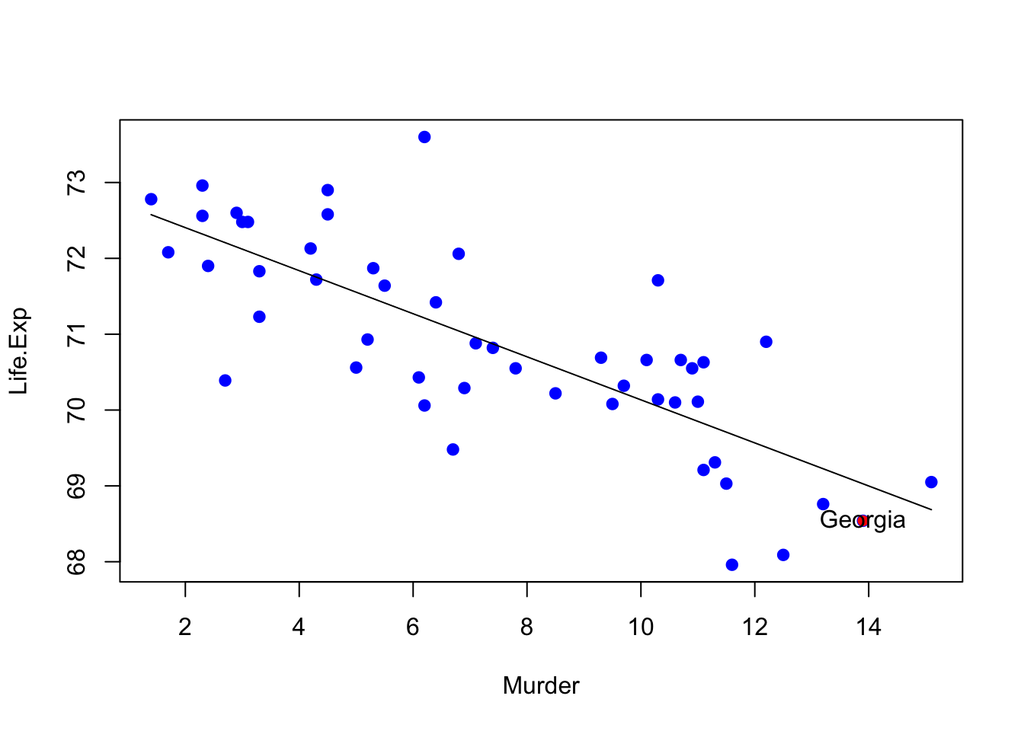

```r
help("points")
plot( Murder, Life.Exp, pch=19, col="blue")
points(13.9, 68.54, pch=16, col="red")
text(13.9, 68.54, "Georgia")
lines(Murder, (72.9736 + (-.2839 * Murder)))
```

```r
model2<-lm(Life.Exp ~ Murder)
model2
```

```
##
## Call:
## lm(formula = Life.Exp ~ Murder)
##
## Coefficients:
## (Intercept)       Murder
##     72.9736      -0.2839
```